# Economía Política Internacional [UCC]

Sebastián Freille

(2021-09-07)

## Clivajes políticos

- Múltiples clivajes políticos en los países –cuáles y por qué cambian es una pregunta clave de política comparada. Ejemplos: religiosos, culturales, industrialización
- Un clivaje menos estudiado –cambios externamente inducidos en la exposición al comercio internacional
- Rogowski (1987) muestra que los resultados del modelo neoclásico de comercio de Heckscher-Ohlin y fundamentalmente el teorema Stolper-Samuelson implica que aumentos/disminuciones en los costos y dificultades asociadas al comercio internacional afectan poderosamente los clivajes políticos internos de manera diferente en países con diferentes dotaciones factoriales

## Teoría neoclásica

> **Teorema de Stolper-Samuelson.** En cualquier país, la protección beneficia (y la liberalización perjudica) a los propietarios de factores en los que el país tiene escasez relativa y también a productores que usan los factores escasos intensivamente. Asimismo, la protección perjudica (y la liberalización beneficia) a los propietarios de factores en el que el país tiene abundancia relativa y también a productores que usan los factores abundantes intensivamente
- En un país rico en $L$ y pobre en $K$, la protección beneficiará al capital y perjudicará al trabajo; la liberalización beneficiará al trabajo y perjudicará al capital

## Pero..

- Cambios exógenos podrían tener exactamente los mismos efectos que aumentos/disminuciones de protección (aranceles a la M)
- Ejemplo: brusca disminución de costos de transporte equivalente a una baja general de aranceles a la M. Del mismo modo para cualquier otro cambio exógeno
- Esto es relevante $\longrightarrow$ cambios en los **riesgos** y **costos** del comercio internacional han sido frecuentes en la historia –vías férreas, buques a vapor, industria refrigeración.

## …y entonces

- Cambios globales de este tipo deberían asociarse a consecuencias globales –en todos los países los propietarios y empleadores de factores relativamente abundantes deberían haberse beneficiado mientras que los propietarios y empleadores de factores relativamente escasos deberían haberse perjudicado
- Los eventos de la década de 1930 deberían haber tenido exactamente el efecto opuesto
- ¿Cuáles habrían sido las **consecuencias políticas** de esas redistribuciones de ingreso/riqueza?

## Modelo simple de política y economía

- Dos supuestos principales sobre el proceso político:
  1. Actores que ganan con un cambio intentan continuarlo y acelerarlo; actores que pierden con un cambio intentan detenerlo y desacelerarlo
  2. Actores con brusco aumento en su ingreso/riqueza ven posible incrementar su influencia política
- Traduciendo en términos de comercio internacional:
  1. Ganadores con el cambio exógeno buscarán seguir expandiendo el libre comercio mientras que los perdedores buscarán obtener protección
  2. Ganadores en términos económicos también aumentan su poder (influencia) política

## La economía

- Modelo tradicional de 3 (tres) factores: tierra (T), capital (K) y trabajo (L)
- El ratio $T/L$ informa *totalmente* la dotación de ambos factores
  - Ningún país puede ser abundante (escaso) en ambos factores
- Economía avanzada aquella en que $K/L$ y $K/T$ es alto
- Modelo de dotaciones factoriales hipersimplificado pero que permite categorizar cualquier país en terminos de un simple diagrama

## La economia (cont.)

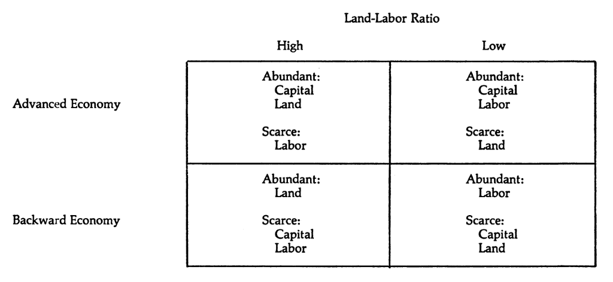

## La política

- El modelo de Stolper-Samuelson (economía) aplicado al simple proceso político (política) implica que un **aumento en la exposición al comercio debe resultar en conflicto urbano-rural en dos tipos de países y en conflicto de clase en los otros dos tipos**
- **Economía avanzada, pobre en $T$.** Aumentos de comercio benefician a $K$ y $L$ y perjudican a $T$. Los sectores urbanos –trabajadores y capitalistas- favorecen el libre comercio, los sectores rurales (i.e. agro) se oponen.
- **Economía atrasada, pobre en $L$.** También surge el conflicto urbano rural; tanto $K$ como $L$ son escasos por lo que pierden ante la apertura comercial y buscarán protección

## La política (cont.)

- **Economía atrasada, pobre en $T$.** Acá surge el **conflicto de clase** –el $L$ va a promover el comercio; terratenientes, capitalistas e industrias manufactureras intensivas en $K$ buscan la protección.
- **Economía avanzada, rica en $T$.** Emerge el conflicto de clase por razones opuestas –los terratenientes, capitalistas y sectores agrarios se benefician y apoyan al comercio; trabajadores e industrias intensivas en mano de obra buscan la protección.
- Estas predicciones tienen alguna validez empírica –Alemania, UK y EEUU en el período 1860/1900.

## La política (cont.)

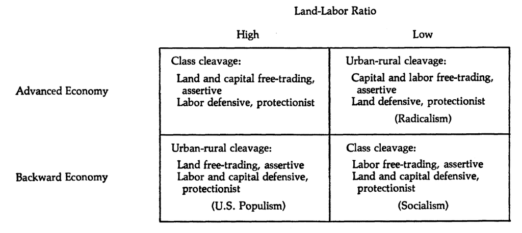

## La política (cont.)

- EEUU y Alemania eran sociedades atrasadas (bajo $K$), pero mientras EEUU era rico en $T$ y pobre en $L$, Alemania era lo opuesto
- Esto predice conflicto de clase en Alemania entre trabajadores promoviendo libre comercio y $K$ y $T$ apoyando proteccionismo
- Para EEUU, la teoría predice conflicto urbano-rural, con el el sector agrario (rural) promoviendo el libre comercio y el sector urbano ($K$,$L$) buscando y apoyando la protección
- UK era un país avanzado con abundancia de $K$ y $L$ –el clivaje era urbano-rural aunque ahora los terranientes promovían la protección.

## La política (cont.)

> **Implicancias y cambios políticos.** En UK, el $K$ y $L$ efectivamente se unieron en el partido Liberal y trajeron cambios como el sufragio extendido y un recorte del poder aristocrático terrateniente. En Alemania, con el liberalismo retraido, el sufragio fue recortado y lejos de erosionar el poder aristocrático, la burguesía aumentó su poder

## Menor exposición al comercio

- Cuando el comercio se restringe, los ganadores y perdedores cambian –propietarios de factores escasos ganan y propietarios de factores abundantes pierden (con el agravante de que no pueden promover más proteccionismo, el proteccionismo viene con las condiciones!)
- **Economía avanzada, rica en $T$.**. Se da un conflicto de clase por parte de una clase trabajadora agresiva. El $K$ y $T$ pierden pero el $L$ gana y tratará de ganar poder político.
- **Economía avanzada, rica en $L$.** Aparece conflicto urbano-rural ya que el agro (escaso) se beneficia y buscará que se mantenga esta situación

## Menor exposición al comercio (cont.)

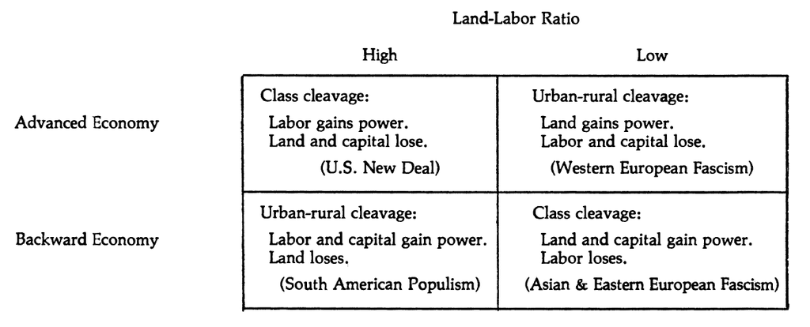

## Menor exposición al comercio (cont.)

- El New Deal en EEUU fue un ejemplo de coalición que incrementó el poder político de los sindicatos de trabajadores. Alternativamente, en Alemania, con otras dotaciones y ante una depresión similar, emergieron procesos dictatoriales con gran influencia política de la clase agraria
- En América Latina, la Depresión generó (o al menos fortaleció) coaliciones “populistas” que unieron $L$ y $K$ (clases medias urbanas) en oposición a la clase terraniente.
- En Asia, y en Japón más especificamente, la influencia militar suprimió las organizaciones de trabajadores favoreciendo al $K$ y $T$.